# Exploração e preparação de dados para análise preditiva

14/08/2020

## Quem sou eu?

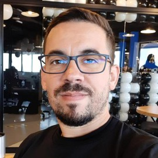

##### Antonio C. da Silva Júnior

Cientista de dados

- Especialização em Data Science e Big Data (UFPR)
- Tecnologia em Análise e Desenvolvimento de Sistemas (UNIP)
- Técnico em Eletrônica (IFSP)

[figure not shown]

## O Kaggle

- https://www.kaggle.com
- Rede social de profissionais e entusiastas da ciência de dados
- Hospedagem de competições de aprendizado de máquina

## As competições

- Classificar quais passageiros sobreviveram ao naufrágio
- Exemplo de dados: sexo, idade, porto de embarque, classe, tarifa…
- Parte dos dados não contém a informação se o passageiro sobreviveu ou não

## Análise preditiva

- Quais perguntas eu quero responder?
- Exploração e preparação dos dados
- Treinamento do modelo preditivo
- Validação dos resultados

## Exploração e preparação dos dados

- Compreender o que os dados “dizem”
- Corrigir inconsistências e realizar transformações
- Lidar com dados ausentes
- Sempre lembrar: entra lixo, sai lixo!

## Dados ausentes

- Por que os dados estão faltando?
- Dado ausente ou censurado? (ex: locadora)
- Normalmente estão associados a um subconjunto de variáveis
- Podem estar associados a um subconjunto de observações

## Lidando com dados ausentes

- Em conjuntos de dados muito grandes a exclusão pode ser a melhor saída
- Em conjuntos de dados pequenos a exclusão pode ter um custo alto
- Imputação de valores ausentes com um modelo KNN (KUHN; JOHNSON, 2013; TROYANSKAYA et al., 2001)

## O KNN

- K-Nearest Neighbours (K vizinhos mais próximos)
- Pode ser aplicado tanto em problemas de classificação como de regressão

## O KNN em um problema de regressão

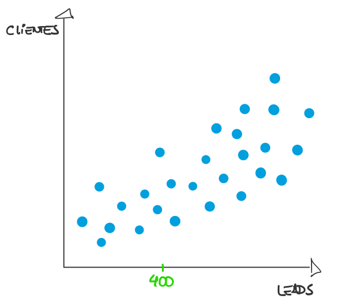

## O KNN em um problema de regressão

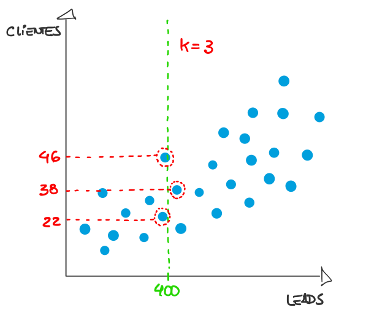

## O KNN em um problema de regressão

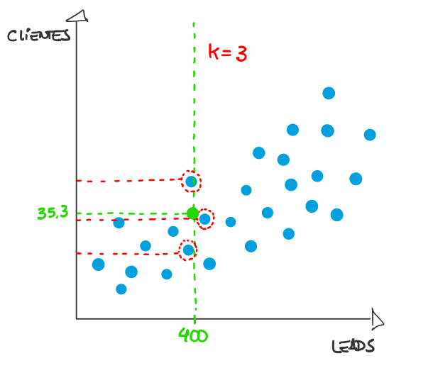

## O KNN em um problema de classificação

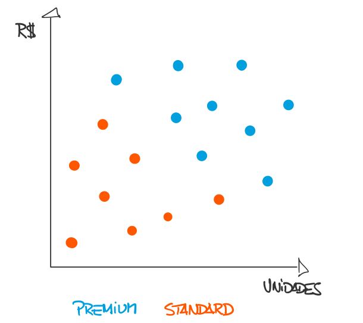

## O KNN em um problema de classificação

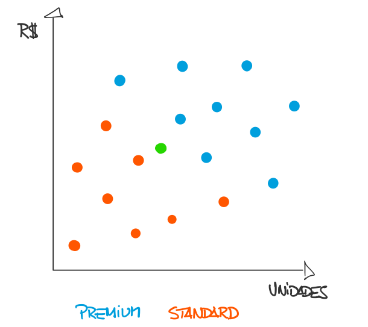

## O KNN em um problema de classificação

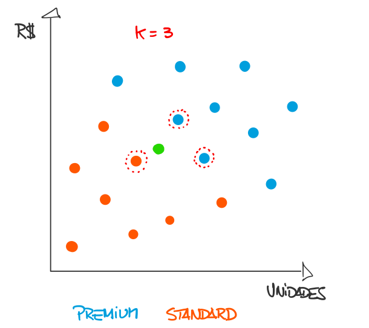

## O KNN em um problema de classificação

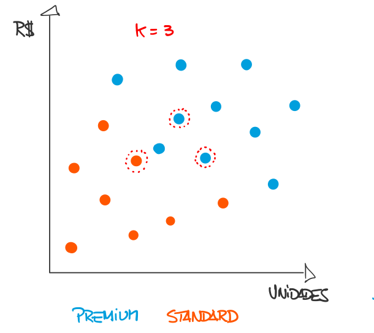

## Validação cruzada por K-Fold

- Técnica para separação dos dados de treino e validação do modelo
- Propósito de reduzir o viés e a variância

## Validação cruzada por K-Fold

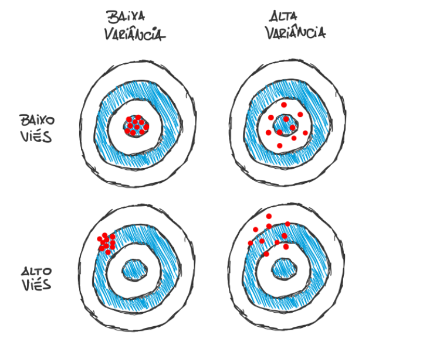

## Validação cruzada por K-Fold (5 folds)

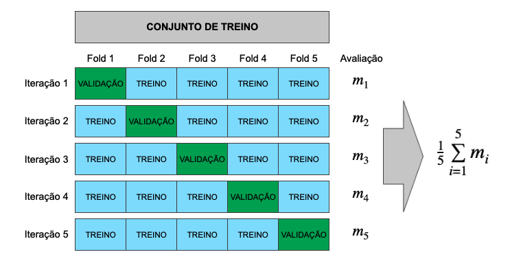

## Número de vizinhos ideal

- Define um vetor de \(k\) vizinhos (normalmente números ímpares)
- Treina e valida um modelo para cada \(k\)
- Escolhe o modelo que apresentar a melhor métrica
- Em problemas de regressão normalmente se mede o erro quadrático
- Em problemas de classificação normalmente se mede a acurácia

## Número de vizinhos ideal

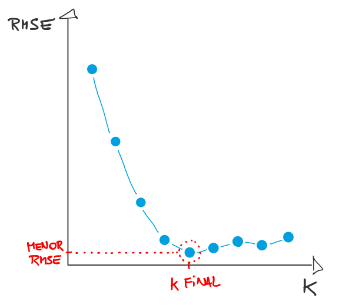

## Hora de sujar as mãos!

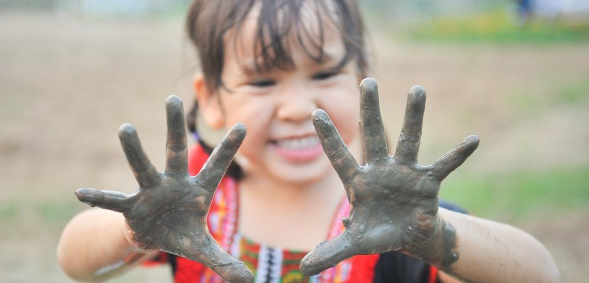

## Download dos recursos no GitHub

- https://github.com/juniorssz/kaggle_titanic

[figure not shown]

## Bibliotecas necessárias

- [dplyr](https://www.rdocumentation.org/packages/dplyr/versions/0.7.8) (manipulação de dados)
- [stringr](https://www.rdocumentation.org/packages/stringr/versions/1.4.0) (manipulação de texto)
- [ggplot2](https://www.rdocumentation.org/packages/ggplot2/versions/3.3.2) (construção de gráficos)
- [fastDummies](https://www.rdocumentation.org/packages/fastDummies/versions/1.6.1) (criação de variáveis dummies)
- [caret](https://www.rdocumentation.org/packages/caret/versions/4.23) (treinamento por validação cruzada)

## Dicionário de dados

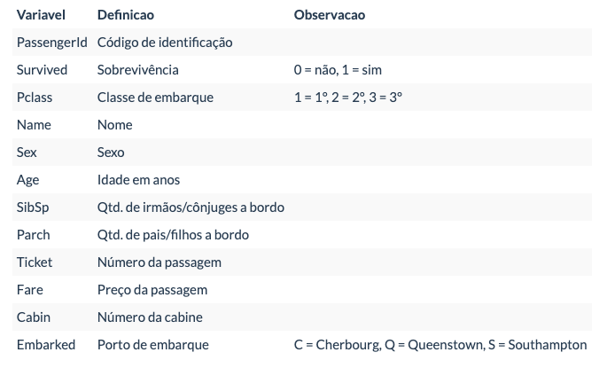

## Perguntas?

[figure not shown]

## Obrigado!

[figure not shown]

juniorssz@gmail.com

[figure not shown]

[+55 41 987827799](https://web.whatsapp.com/send?phone=5541987827799)

[figure not shown]

juniorssz.github.io/home/

[figure not shown]

juniorssz

[figure not shown]

[in/juniorssz](https://www.linkedin.com/in/juniorssz/)

[figure not shown]

9538279526734312

## Referências

FÁVERO, L. P.; BELFIORE, P. **Manual de análise de dados: estatística e modelagem multivariada com Excel, SPSS e Stata**. [s.l.] Elsevier Brasil, 2017.

KUHN, M.; JOHNSON, K. **Applied predictive modeling**. [s.l.] Springer, 2013. v. 26

TROYANSKAYA, O. et al. Missing value estimation methods for DNA microarrays. **Bioinformatics**, v. 17, n. 6, p. 520–525, 2001.